# Stat435_HW1

Su Huang

4/4/2022

### problem 1

1. Suppose that you are interested in performing regression on a particular dataset, in order to answer a particular scientific question. You need to decide whether to take a parametric or a non-parametric approach.
1. In general, what are the pros and cons of taking a parametric versus a non-parametric approach?

   The pros of parametric approach: it reduces the problem of estimating f down to one of estimating a set of parameters; Less data needed; easy and faster to interpret.

   The cons of parametric approach: the model we choose may not fit into the true known form of f which will lead to large error and poor estimate. And fitting a more flexible model requires more number of parameters and generate overfitting.

   The pros of non-parametric approach: avoid the assumption of a functional form for f, they have the potential to accurately fit a wider range of possible shapes for f.

   The cons of non-parametric approach: since they do not reduce the problem of estimating f to a small number of parameters, more data and longer time is required for estimate;
2. What properties of the data or scientific question would lead you to take a parametric approach?

   The question has small size of data and look for a understandable and interpretable prediction.
3. What properties of the data or scientific question would lead you to take a non-parametric approach?

   The questions we don’t want to make improper assumptions, no requirement on efficiency and have large size of data.

### problem 2

2. In each setting, would you generally expect a flexible or an inflexible statistical machine learning method to perform better? Justify your answer.
1. Sample size n is very small, and number of predictors p is very large.

   Inflexible method is better because the probability of overfitting will be high with a small sample size and large p. Small size n is not enough for flexible method.
2. Sample size n is very large, and number of predictors p is very small.

   Flexible method is better because it could fit data better and large sample size promotes the better prediction.
3. Relationship between predictors and response is highly non-linear.

   Flexible method is better because it’s necessary to use a flexible method to find non-linear effect.
4. The variance of the error terms, i.e. σ2 = Var(), is extremely high.

   Inflexible method is better because when we have high variance, the flexible method will try to learn and apply the noise term which may bring more test error.

## problem 3

3. For each scenario, determine whether it is a regression or a classification prob- lem, determine whether the goal is inference or prediction, and state the values of n (sample size) and p (number of predictors).
1. I want to predict each student’s final exam score based on his or her homework scores. There are 50 students enrolled in the course, and each student has completed 8 homeworks.

   Regression and prediction; n=50, p=8. The score is quantitative and we wants to predict score.
2. I want to understand the factors that contribute to whether or not a student passes this course. The factors that I consider are (i) whether or not the student has previous programming experience; (ii) whether or not the student has previously studied linear algebra; (iii) whether or not the student has taken a previous stats/probability course; (iv) whether or not the student attends office hours; (v) the student’s overall GPA; (vi) the student’s year (e.g. freshman, sophomore, junior, senior, or grad student). I have data for all 50 students enrolled in the course.

   Classification and inference; n=50, p=6. These factors are not quantitative.

## problem 4

4. This problem has to do with the bias-variance trade-off and related ideas, in the context of regression. For (a) and (b), it’s okay to submit hand-sketched plots: you are not supposed to actually compute the quantities referred to below on data; instead, this is a thought exercise.
1. Make a plot, like the one we saw in class, with “flexibility” on the x- axis. Sketch the following curves: squared bias, variance, irreducible error, reducible error, expected prediction error. Be sure to label each curve. Indicate which level of flexibility is “best”.

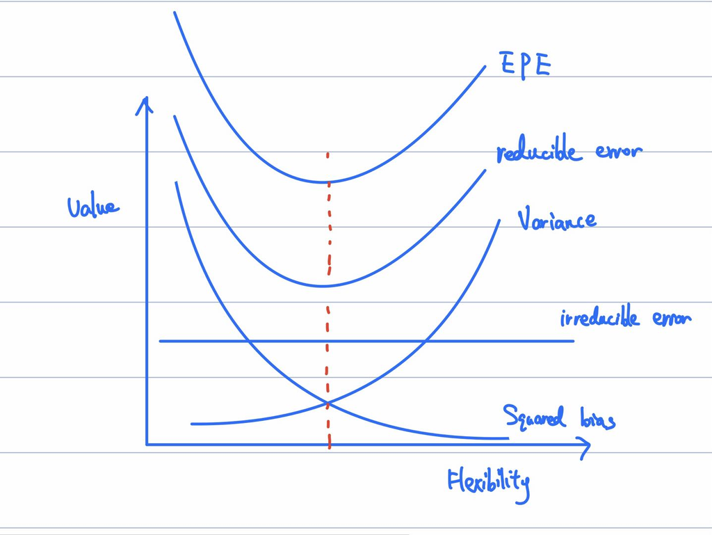

   The best flexibility level the lowest expected prediction error.
2. Make a plot with “flexibility” on the x-axis. Sketch curves corresponding to the training error and the test error. Be sure to label each curve. Indicate which level of flexibility is “best”.

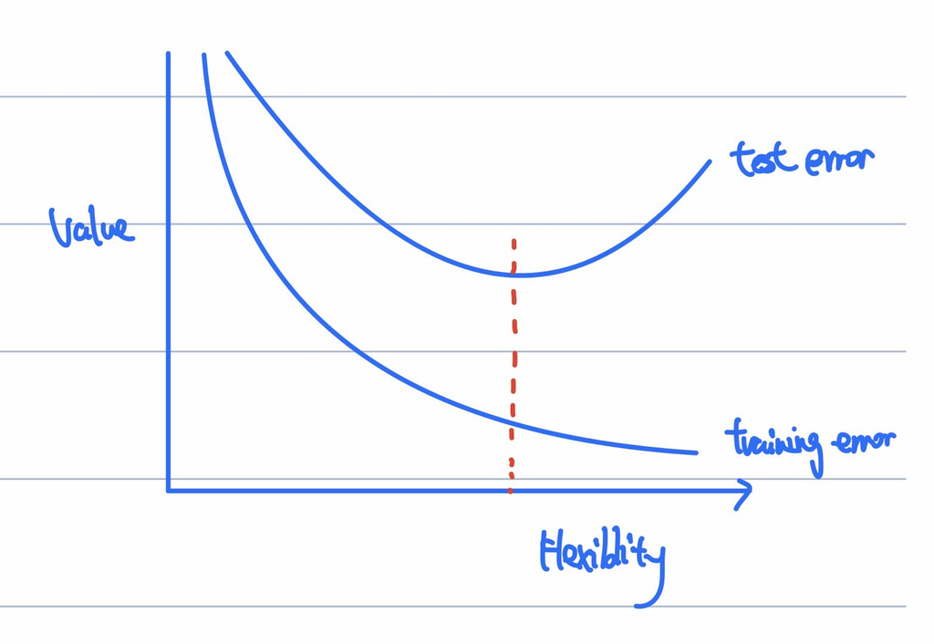

   The best flexibility level is when we have the smallest test error.
3. Describe an ˆf that has extremely low bias, and extremely high variance. Explain your answer.

   more flexible methods have low bias because it can fit into the data easily and higher variance because changing any data will cause f change considerably
4. Describe an ˆf that has extremely high bias, and zero variance. Explain your answer.

   inflexible methods has high bias because inflexible method might not be able to fit the data properly in many cases and low variance because moving any single data will likely cause only a small change of the whole prediction.

## problem 5

We now consider a classification problem. Suppose we have 2 classes (labels), 25 observations per class, and p = 2 features. We will call one class the “red” class and the other class the “blue” class. The observations in the red class are drawn i.i.d. from a Np(μr,I) distribution, and the observations in the blue class are drawn i.i.d. from a Np(μb,I) distribution, where μr =(0 0) is the mean in the red class, and where μb = (1.5 1.5) is the mean in the blue class. (a) Generate a training set, consisting of 25 observations from the red class and 25 observations from the blue class. (You will want to use the R function rnorm.) Plot the training set. Make sure that the axes are properly labeled, and that the observations are colored according to their class label.

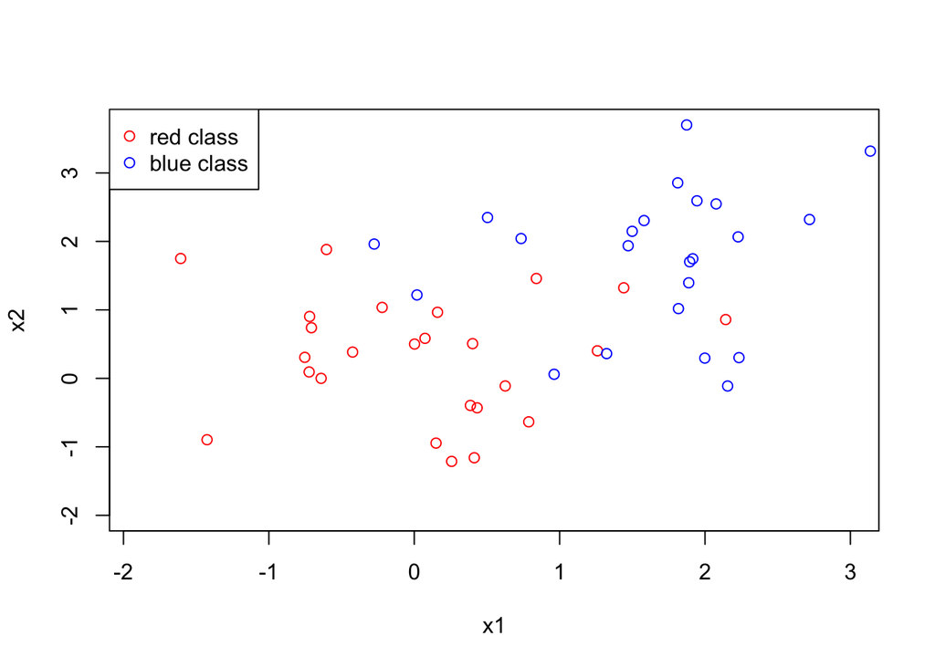

```r
library(ggplot2)
set.seed(435)

red <- data.frame(X1 = rnorm(25, 0, 1), X2 = rnorm(25, 0, 1)) %>%
  mutate(color = "red")

blue <- data.frame(X1 = rnorm(25, 1.5, 1), X2 = rnorm(25, 1.5, 1)) %>%
  mutate(color = "blue")

train <- rbind(red, blue)

plot(train$X1, train$X2, xlab="x1",ylab="x2",col=train$color,xlim=c(-1.9,3), ylim=c(-2,3.7))
legend(x="topleft",  legend=c("red class", "blue class"),
       col=c("red", "blue"),
       pch = c(1,1)
       )
```

2. Now generate a test set consisting of 25 observations from the red class and 25 observations from the blue class. On a single plot, display both the training and test set, using one symbol to indicate training observations (e.g. circles) and another symbol to indicate the test observations (e.g. squares). Make sure that the axes are properly labeled, that the symbols for training and test observations are explained in a legend, and that the observations are colored according to their class label.

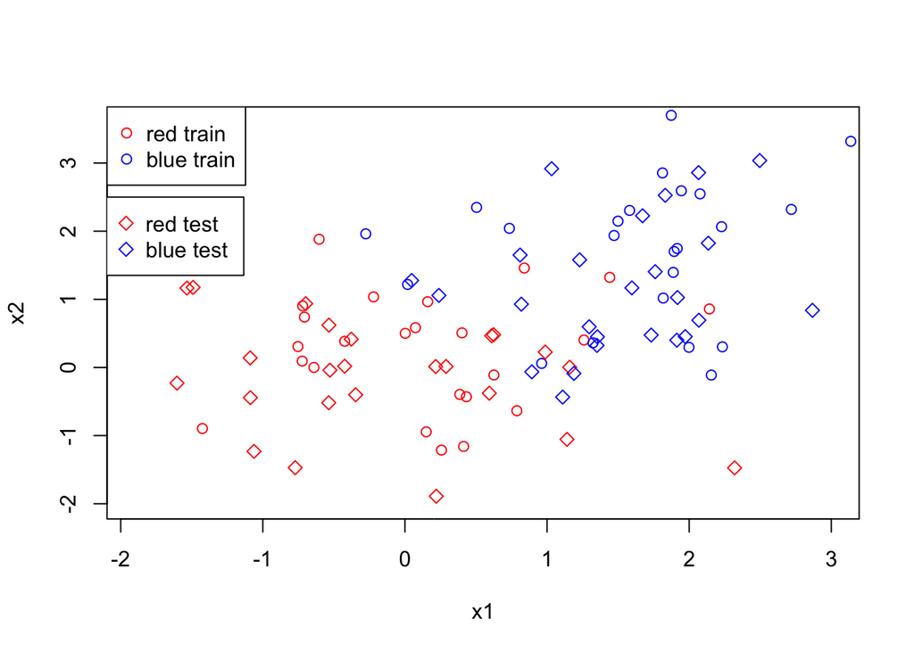

```r
red_test <- data.frame(X1 = rnorm(25, 0, 1), X2 = rnorm(25, 0, 1)) %>%
  mutate(color = "red")

blue_test <- data.frame(X1 = rnorm(25, 1.5, 1), X2 = rnorm(25, 1.5, 1)) %>%
  mutate(color = "blue")

test <- rbind(red_test, blue_test)


plot(train$X1, train$X2, xlab="x1",ylab="x2",col=train$color,xlim=c(-1.9,3), ylim=c(-2,3.6))
points(test$X1, test$X2, col = test$color, pch=5)
legend(x="topleft",  legend=c("red train", "blue train"),
       col=c("red", "blue"),
       pch = c(1,1),cex=1
       )
legend(x=-2.1, y= 2.5,  legend=c("red test", "blue test "),
       col=c("red", "blue"),
       pch = 5, cex=1
       )
```

3. Using the knn function in the library class, fit a k-nearest neighbors model on the training set, for a range of values of k from 1 to 20. Make a plot that displays the value of 1/k on the x-axis, and classification error (both training error and test error) on the y-axis. Make sure all axes and curves are properly labeled. Explain your results.

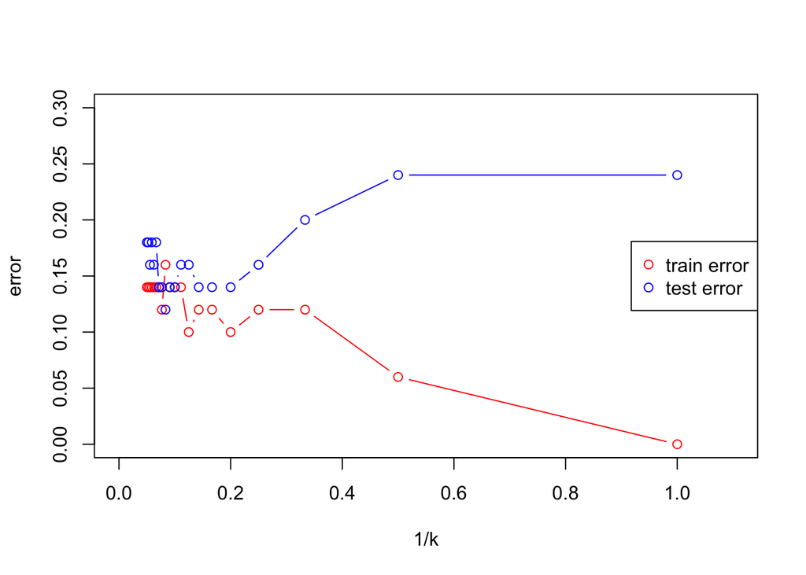

```
We have the smallest error when 1/k is less than 0.2, which means quite large k and small k are both not appropriate for knn. We have a train error equals 0 because when k = 1, it compares to itself.
```

```r
library(class)
result <- data.frame(k = rep(0,20), train_error = rep(0,20), test_error = rep(0,20))
trai <- train[,1:2]
tes <- test[,1:2]

for (i in 1:20){

  train_k <- class::knn(trai, trai, train$color, k=i)
  train_error <- mean(train_k != train$color)

  test_k <- class::knn(trai, tes, train$color, k=i)
  test_error <- mean(test_k != test$color)

  result[i,"k"] <- i
  result[i,"train_error"] <- train_error
  result[i, "test_error"] <- test_error
}

plot(1/result$k, result$train_error, type="b", col = "red", xlim = c(0, 1.1), ylim = c(0, 0.3), xlab ="1/k", ylab="error" )
points(1/result$k, result$test_error, type="b", col = "blue")
legend(x="right",  legend=c("train error", "test error"),
       col=c("red", "blue"),
       pch = c(1,1),cex=1)
```

4. For the value of k that resulted in the smallest test error in part (c) above, make a plot displaying the test observations as well as their true and predicted class labels. Make sure that all axes and points are clearly labeled.

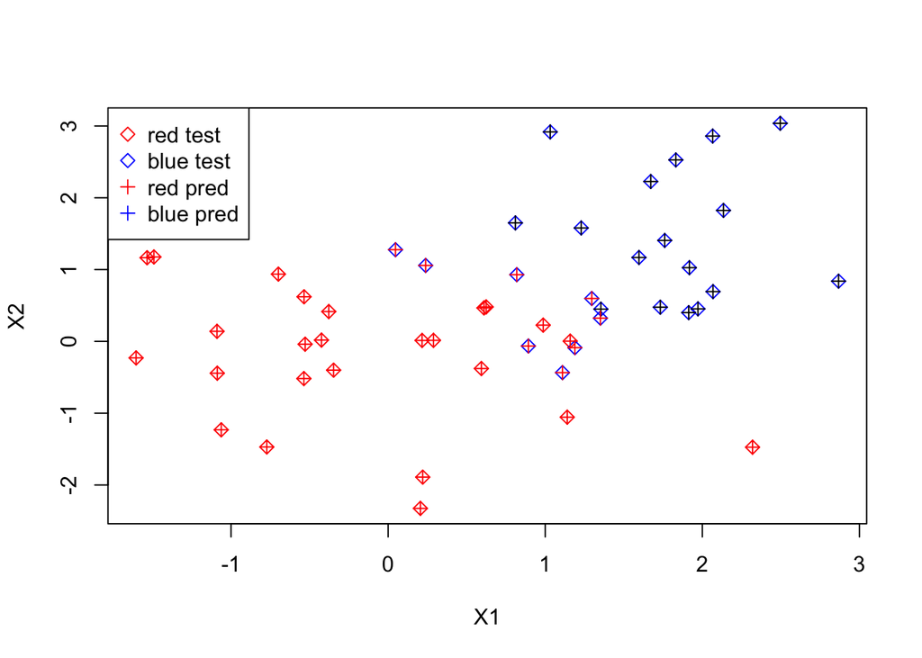

```r
min_k<-result$k[result$test_error==min(result$test_error)]

plot(test$X1, test$X2, col = test$color, pch=5, xlab = "X1", ylab = "X2")
points(test$X1, test$X2, col = class::knn(trai, tes, train$color, k=min_k), pch=3)
legend(x="topleft",  legend=c("red test", "blue test", "red pred", "blue pred"),
       col=c("red", "blue", "red", "blue"),
       pch = c(5,5,3,3),cex=1)
```

5. Recall that the Bayes classifier assigns an observation to the red class if Pr(Y = red|X = x) > 0.5, and to the blue class otherwise. The Bayes error rate is the error rate associated with the Bayes classifier. What is the value of the Bayes error rate in this problem? Explain your answer.

```r
#train$redp <- dnorm(train$X1) * dnorm(train$X2)
#train$bluep <- dnorm(train$X1, 1.5) * dnorm(train$X2, 1.5)
B <- table(class::knn(trai, tes, train$color, k=min_k), test$color)
1-sum(diag(B))/sum(B)
```

[output not shown]

6. We will once again perform k-nearest-neighbors in a setting with p = 2 features. But this time, we’ll generate the data differently: let X1 ∼ Unif[0,1] and X2 ∼Unif[0,1], i.e. the observations for each feature are i.i.d. from a uniform distribution. An observation belongs to class “red” if (X1−0.5)2+(X2−0.5)2 > 0.15 and X1 > 0.5; to class “green” if (X1 −0.5)2 + (X2 −0.5)2 > 0.15 and X1 ≤0.5; and to class “blue” otherwise.
1. Generate a training set of n = 200 observations. (You will want to use the R function runif.) Plot the training set. Make sure that the axes are properly labeled, and that the observations are colored according to their class label.

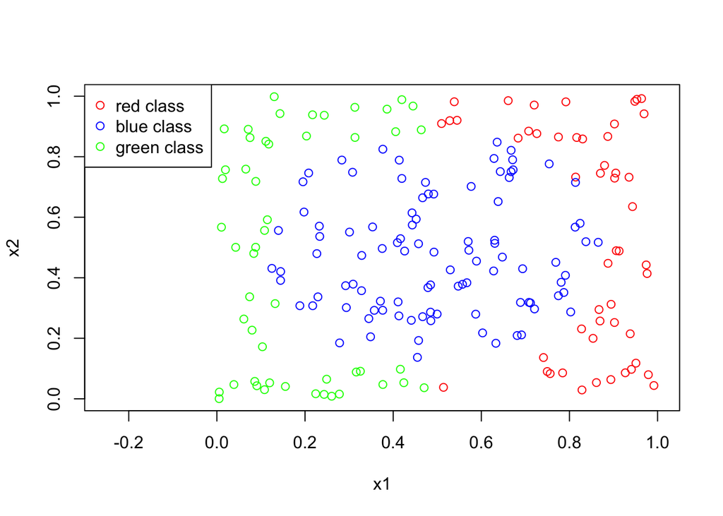

```r
data <- data.frame(X1 = runif(200, 0, 1), X2 = runif(200, 0, 1)) %>%
  mutate(Color = ifelse((X1-0.5)^2+(X2-0.5)^2 > 0.15,
                    ifelse(X1 > 0.5, "red", "green"), "blue"))

plot(data$X1, data$X2, xlab="x1", ylab="x2", col=data$Color, xlim = c(-0.25,1))
legend(x="topleft",  legend=c("red class", "blue class", "green class"),
       col=c("red", "blue", "green"),
       pch = 1
       )
```

2. Now generate a test set consisting of another 200 observations. On a single plot, display both the training and test set, using one symbol to indicate training observations (e.g. circles) and another symbol to indicate the test observations (e.g. squares). Make sure that the axes are properly labeled, that the symbols for training and test observations are explained in a legend, and that the observations are colored according to their class label.

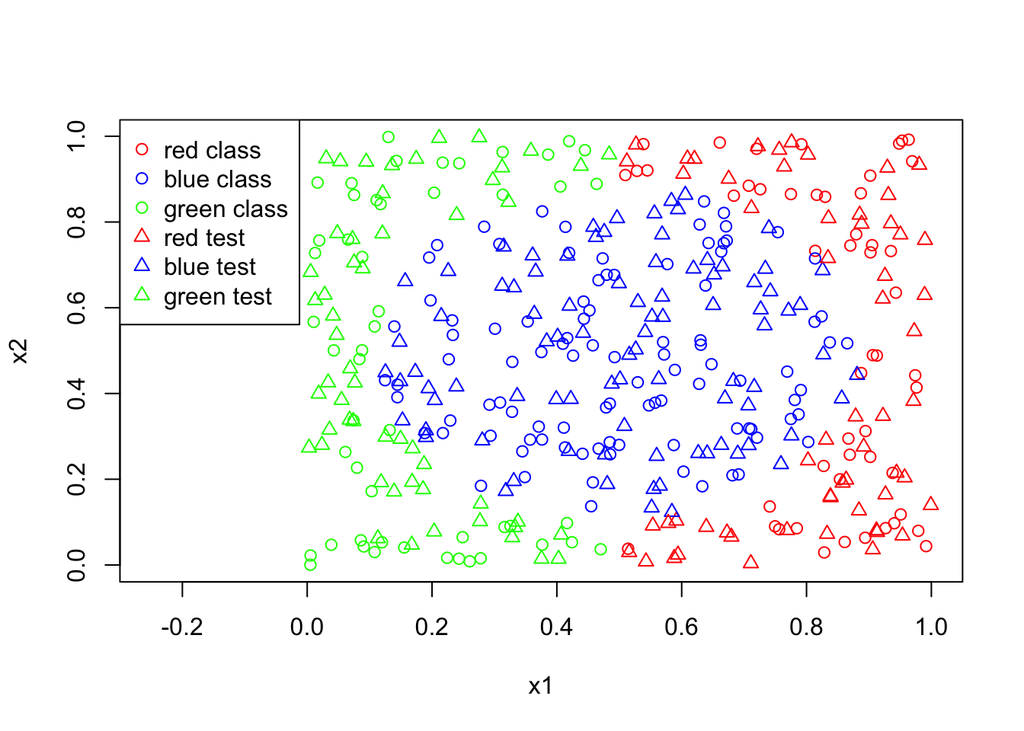

```r
data_test <- data.frame(X1 = runif(200, 0, 1), X2 = runif(200, 0, 1)) %>%
  mutate(Color = ifelse((X1-0.5)^2+(X2-0.5)^2 > 0.15,
                    ifelse(X1 > 0.5, "red", "green"), "blue"))

plot(data$X1, data$X2, xlab="x1", ylab="x2", col=data$Color, pch = 1, xlim = c(-0.25,1))
points(data_test$X1, data_test$X2, col=data_test$Color, pch = 2)
legend(x="topleft",  legend=c("red class", "blue class", "green class", "red test", "blue test", "green test"),
       col=c("red", "blue", "green", "red", "blue", "green"),
       pch = c(1,1,1,2,2,2)
       )
```

3. Using the knn function in the library class, fit a k-nearest neighbors model on the training set, for a range of values of k from 1 to 50. Make a plot that displays the value of 1/k on the x-axis, and classification error (both training error and test error) on the y-axis. Make sure all axes and curves are properly labeled. Explain your results.

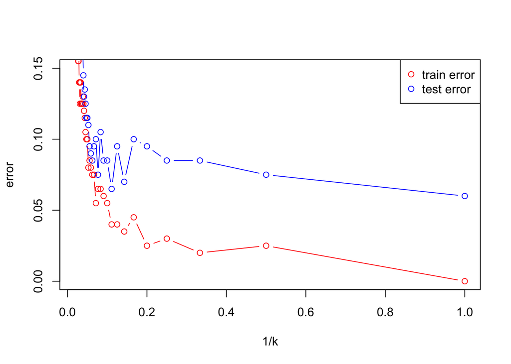

[output not shown]

```r
result2 <- data.frame(k = rep(0,50), train_error=rep(0,50), test_error=rep(0,50))
data3 <- data[,1:2]
data_test3 <- data_test[,1:2]

for (i in 1:50){

  train_k <- class::knn(data3, data3, data$Color, k=i)
  train_error <- mean(train_k != data$Color)

  test_k <- class::knn(data3, data_test3, data$Color, k=i)
  test_error <- mean(test_k != data_test$Color)

  result2[i,"k"] <- i
  result2[i,"train_error"] <- train_error
  result2[i, "test_error"] <- test_error
}

plot(1/result2$k, result2$train_error, type="b", col = "red", ylim = c(0, 0.15), xlab ="1/k", ylab="error" )
points(1/result2$k, result2$test_error, type="b", col = "blue")
legend(x="topright",  legend=c("train error", "test error"),
       col=c("red", "blue"),
       pch = c(1,1),cex=1)
```

4. For the value of k that resulted in the smallest test error in part (c) above, make a plot displaying the test observations as well as their true and predicted class labels. Make sure that all axes and points are clearly labeled.

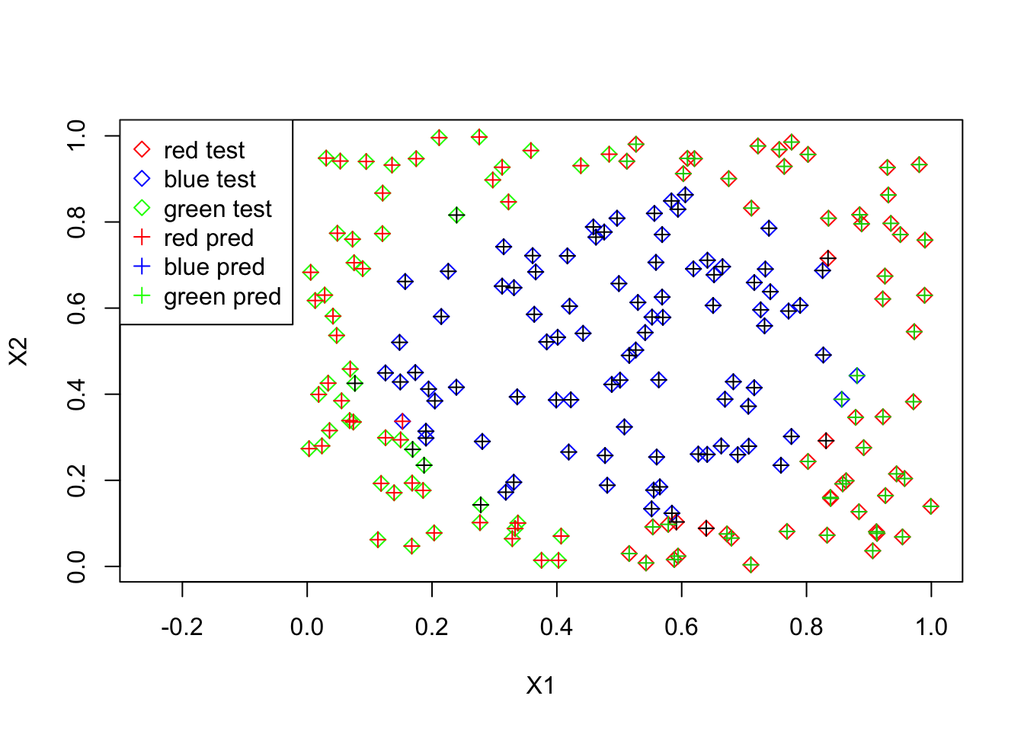

```r
min_k2<-result2$k[result2$test_error == min(result2$test_error)]

plot(data_test$X1, data_test$X2, col = data_test$Color, pch = 5, xlab = "X1", ylab = "X2", xlim = c(-0.25,1))
points(data_test$X1, data_test$X2, col = class::knn(data3, data_test3, data$Color, k=min_k2), pch = 3)
legend(x ="topleft", legend = c("red test", "blue test", "green test", "red pred", "blue pred", "green pred"),
       col = c("red", "blue","green", "red", "blue","green"),
       pch = c(5,5,5,3,3,3), cex = 1)
```

5. In this example, what is the Bayes error rate? Justify your answer, and explain how it relates to your findings in (c) and (d).

```r
B <- table(class::knn(data3, data_test3, data$Color, k=min_k2), data_test$Color)
1-sum(diag(B))/sum(B)
```

```
## [1] 0.06
```

7. This exercise involves the Boston housing data set, which is part of the ISLR2 library.
1. How many rows are in this data set? How many columns? What do the rows and columns represent?

```r
library(ISLR2)
ncol(Boston)
```

```
## [1] 13
```

```r
nrow(Boston)
```

```
## [1] 506
```

```
There are 13 columns, and 506 rows.
The row represents the number of house we have.
The column represents the factors or the parameters that are contained for each house.
```

2. Make some pairwise scatterplots of the predictors (columns) in this data set. Describe your findings.

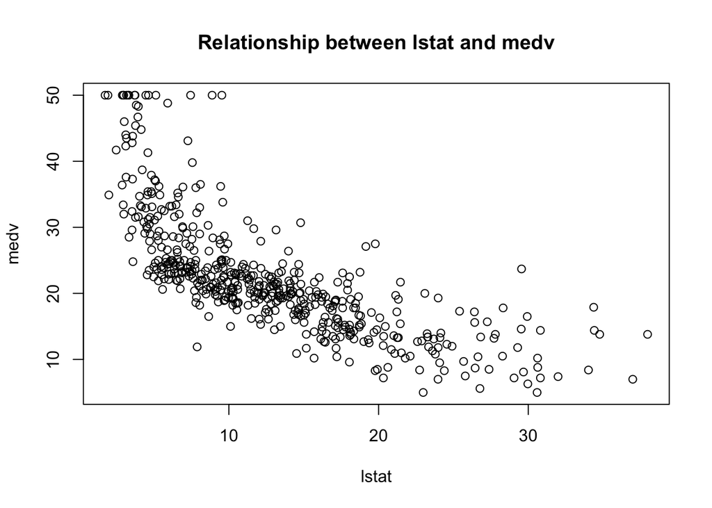

```
Istat and medv has negative relationship. Medc decreases when the lstat increases.
```

```r
plot(Boston$lstat, Boston$medv,
     main="Relationship between lstat and medv",
     xlab="lstat", ylab="medv")
```

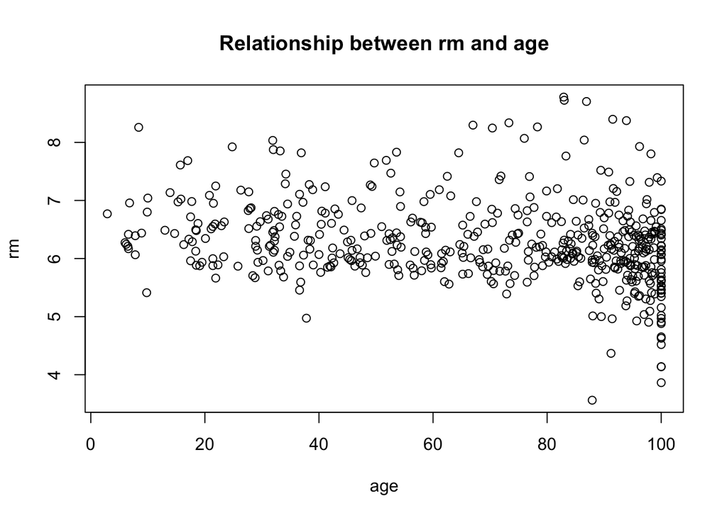

```
The room number is pretty consistent around 6 or 7 regardless of the house age.
```

```r
plot(Boston$age, Boston$rm,
     main="Relationship between rm and age",
     xlab="age", ylab="rm")
```

[figure not shown]

[output not shown]

```r
plot(Boston$crim, Boston$dis,
     main="Relationship between crim and medv",
     xlab="crim", ylab="medv", xlim = c(0,1))
```

3. Are any of the predictors associated with per capita crime rate? If so, explain the relationship.

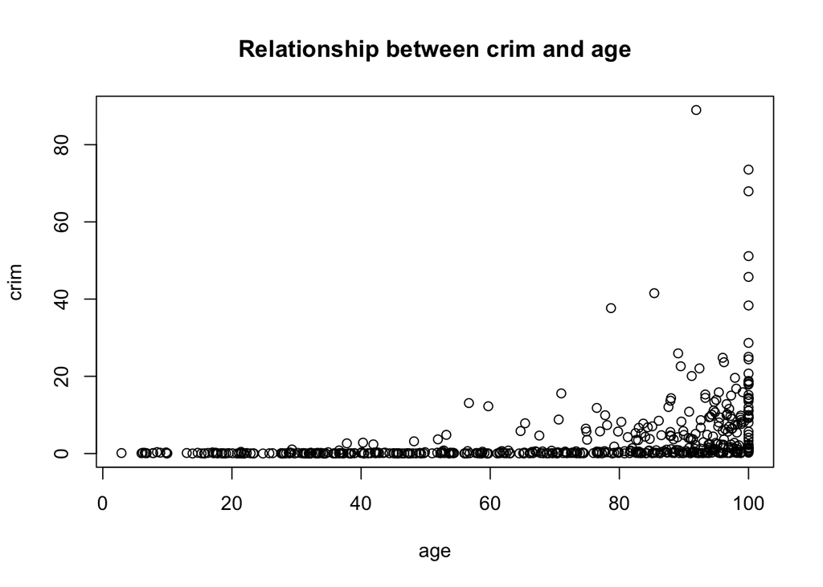

[output not shown]

```r
plot(Boston$age, Boston$crim,
     main="Relationship between crim and age",
     xlab="age", ylab="crim")
```

4. Do any of the suburbs of Boston appear to have particularly high crime rates? Tax rates? Pupil-teacher ratios? Comment on the range of each predictor.

```r
range(Boston$crim)
```

```
## [1]  0.00632 88.97620
```

```r
range(Boston$tax)
```

```
## [1] 187 711
```

```r
range(Boston$ptratio)
```

```
## [1] 12.6 22.0
```

```
The range of crime rates is between 0.00632 and 88.9762
The range of tax rates is between 187 and 711
The range of pupil teacher ratios is between 12.6 and 22
```

5. How many of the suburbs in this data set bound the Charles river?

```r
nrow(Boston[Boston$chas == 1,])
```

```
## [1] 35
```

```
There are 35 suburbs bounding the Charles river.
```

6. What are the mean and standard deviation of the pupil-teacher ratio among the towns in this data set?

```r
mean(Boston$ptratio)
```

```
## [1] 18.45553
```

```r
sd(Boston$ptratio)
```

```
## [1] 2.164946
```

```
The mean of the pupil-teacher ratio is 18.45553
The sd is 2.164946
```

7. Which suburb of Boston has highest median value of owner-occupied homes? What are the values of the other predictors for that suburb, and how do those values compare to the overall ranges for those predictors? Comment on your findings.

```r
Boston[Boston$medv == max(Boston$medv),]
```

```
##        crim zn indus chas    nox    rm   age    dis rad tax ptratio lstat medv
## 162 1.46336  0 19.58    0 0.6050 7.489  90.8 1.9709   5 403    14.7  1.73   50
## 163 1.83377  0 19.58    1 0.6050 7.802  98.2 2.0407   5 403    14.7  1.92   50
## 164 1.51902  0 19.58    1 0.6050 8.375  93.9 2.1620   5 403    14.7  3.32   50
## 167 2.01019  0 19.58    0 0.6050 7.929  96.2 2.0459   5 403    14.7  3.70   50
## 187 0.05602  0  2.46    0 0.4880 7.831  53.6 3.1992   3 193    17.8  4.45   50
## 196 0.01381 80  0.46    0 0.4220 7.875  32.0 5.6484   4 255    14.4  2.97   50
## 205 0.02009 95  2.68    0 0.4161 8.034  31.9 5.1180   4 224    14.7  2.88   50
## 226 0.52693  0  6.20    0 0.5040 8.725  83.0 2.8944   8 307    17.4  4.63   50
## 258 0.61154 20  3.97    0 0.6470 8.704  86.9 1.8010   5 264    13.0  5.12   50
## 268 0.57834 20  3.97    0 0.5750 8.297  67.0 2.4216   5 264    13.0  7.44   50
## 284 0.01501 90  1.21    1 0.4010 7.923  24.8 5.8850   1 198    13.6  3.16   50
## 369 4.89822  0 18.10    0 0.6310 4.970 100.0 1.3325  24 666    20.2  3.26   50
## 370 5.66998  0 18.10    1 0.6310 6.683  96.8 1.3567  24 666    20.2  3.73   50
## 371 6.53876  0 18.10    1 0.6310 7.016  97.5 1.2024  24 666    20.2  2.96   50
## 372 9.23230  0 18.10    0 0.6310 6.216 100.0 1.1691  24 666    20.2  9.53   50
## 373 8.26725  0 18.10    1 0.6680 5.875  89.6 1.1296  24 666    20.2  8.88   50
```

```
There are 16 of them having highest medv. Other predictors variate depending on the specific suburbs. I didnt see any predictors have an consistently extreme values among these suburbs.
```

8. In this data set, how many of the suburbs average more than six rooms per dwelling? More than eight rooms per dwelling? Comment on the suburbs that average more than eight rooms per dwelling.

```r
library(dplyr)
nrow(Boston[Boston$rm > 6,])
```

```
## [1] 333
```

```r
nrow(Boston[Boston$rm > 8,])
```

```
## [1] 13
```

There are 333 suburbs that have more than 6 rooms per dwelling and 13 suburbs that have more than 8.